# High School Seniors 2

```r
library(mosaic)
library(DT)
library(pander)
library(car)
library(tidyverse)
library(dplyr)
library(tidyr)
library(readr)
library(ggplot2)
library(plotly)

# Read in the data
HighSchoolSeniors <- read.csv("../../Data/HighSchoolSeniors.csv", header=TRUE)

HSS <- HighSchoolSeniors
HSS <-HSS %>% drop_na()
```

```r
#find Q1, Q3, and interquartile range for values in column family
Q1 <- quantile(HSS$Doing_Things_With_Family_Hours, .25, na.rm = TRUE)
Q3 <- quantile(HSS$Doing_Things_With_Family_Hours, .75, na.rm = TRUE)
IQR <- IQR(HSS$Doing_Things_With_Family_Hours, na.rm = TRUE)

#find Q1, Q3, and interquartile range for values in column Friends
Q1.2 <- quantile(HSS$Hanging_Out_With_Friends_Hours, .25, na.rm = TRUE)
Q3.2 <- quantile(HSS$Hanging_Out_With_Friends_Hours, .75, na.rm = TRUE)
IQR.2 <- IQR(HSS$Hanging_Out_With_Friends_Hours, na.rm = TRUE)

#only keep rows in dataframe that have values within 1.5*IQR of Q1 and Q3
HSS_C <- subset(HSS, HSS$Doing_Things_With_Family_Hours> (Q1 - 1.5*IQR) & HSS$Doing_Things_With_Family_Hours< (Q3 + 1.5*IQR))
HSS_C_ <- subset(HSS_C, HSS_C$Hanging_Out_With_Friends_Hours> (Q1 - 1.5*IQR.2) & HSS_C$Hanging_Out_With_Friends_Hours< (Q3 + 1.5*IQR.2))
```

```r
HSS_C_$Home_Occupants_F <- case_when(HSS_C_$Home_Occupants <= 3 ~ "Small", HSS_C_$Home_Occupants > 3 & HSS_C_$Home_Occupants <= 4 ~ "Average", HSS_C_$Home_Occupants > 4 ~ "Large" )

HSS_C_$Home_Occupants_F <- as.factor(HSS_C_$Home_Occupants_F)
HSS_C_$Favorite_Season <- as.factor(HSS_C_$Favorite_Season)
```

## Question: Does having more/less siblings affect the amount of time spent with Family vs. Friends, and does a persons favorite season of the year have any relation to these values?

## Hypothesis:

I originally thought large families would spend more time with family and only children would spend more time with friends, my original analysis with t-tests showed no significant value to these relations, I am now curious if personal preferences on season of the year has any relations to these numbers and groups.

For testing purposes the results will be broken into three groups, Small families (82 observations), average families (94 observations), and large families (5+ members in the household, 83 observations). A two way anova will be conducted to analyze the effects of each individual variable, and the affects of each variable on the other.

Does having more/less siblings affect the amount of time spent with Family vs. Friends?
$$H_0: \mu_{Large-Family} = \mu_{Only-Child} = \mu_{Sibling-Pair} = \mu$$

$$H_a: \mu_i \neq \mu \text{ for at least one } \epsilon \{1=LF ,2=OC ,3=SP\}$$

Does Season have an effect on the amount of time spent with Family vs. Friends:
$$H_0: \mu_{Wi} = \mu_{Sp} = \mu_{Su} = \mu_{Fa} = \mu$$
$$H_a: \mu_i \neq \mu \text{ for at least one } \epsilon \{1=Wi ,2=Sp ,3=Su, 4=Fa\}$$
Does Family Size interact with Favorite Season?
$$H_0: \text{The effect of Favorite Season is the same for all Family sizes.}$$
$$H_a: \text{The effect of Favorite Season is not the same for all Family Sizes.}$$

Significance level will be α=0.05.

## Analysis

Below is the two way anova analysis of the data. Below are the Values for our test, as shown we can see that none of the p-values are significant with a level of α=0.05. So there is not a significant effect on the number of hours spent with family based on Favorite Season, or Home Size. We can also see that there is no significant relationship between favorite season and home size.

```r
Fam2.aov <- aov(Doing_Things_With_Family_Hours ~ Favorite_Season + Home_Occupants_F + Favorite_Season:Home_Occupants_F, data=HSS_C_)
summary(Fam2.aov) %>% pander()
```

Analysis of Variance Model

|  | Df | Sum Sq | Mean Sq | F value | Pr(>F) |
| --- | --- | --- | --- | --- | --- |
| **Favorite_Season** | 3 | 98.45 | 32.82 | 1.121 | 0.341 |
| **Home_Occupants_F** | 2 | 50.67 | 25.34 | 0.8658 | 0.422 |
| **Favorite_Season:Home_Occupants_F** | 6 | 210.3 | 35.06 | 1.198 | 0.3079 |
| **Residuals** | 247 | 7228 | 29.26 | NA | NA |

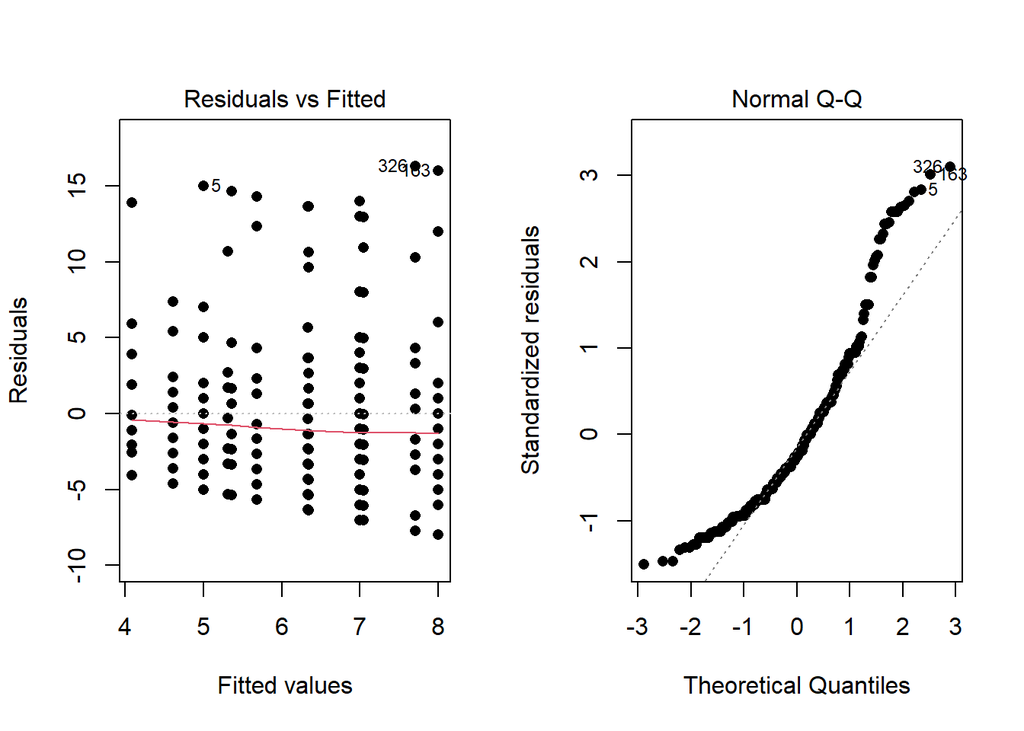

```r
par(mfrow=c(1,2))
plot(Fam2.aov, which=1:2, pch=16)
```

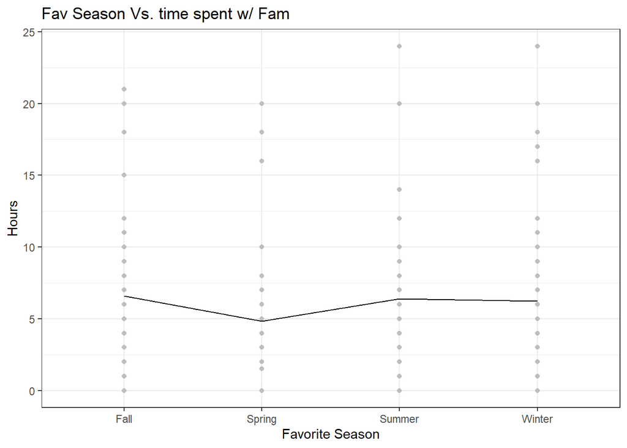

```r
library(dplyr)

ggplot(HSS_C_, aes(x=Favorite_Season, y=Doing_Things_With_Family_Hours, group=1)) +
  geom_point(color="gray") +
  stat_summary(fun="mean", geom="line") +
  labs(title="Fav Season Vs. time spent w/ Fam", x="Favorite Season", y="Hours") +
  theme_bw()
```

```r
HSS_C_ %>%
  group_by(Favorite_Season) %>%
  summarise(`Mean Hours`=mean(Doing_Things_With_Family_Hours, na.rm = TRUE)) %>%
  pander(caption="Mean Hours by Season")
```

Mean Hours by Season

| Favorite_Season | Mean Hours |
| --- | --- |
| Fall | 6.59 |
| Spring | 4.833 |
| Summer | 6.405 |
| Winter | 6.242 |

There is not any significant variance of time spent with family due to favorite season.

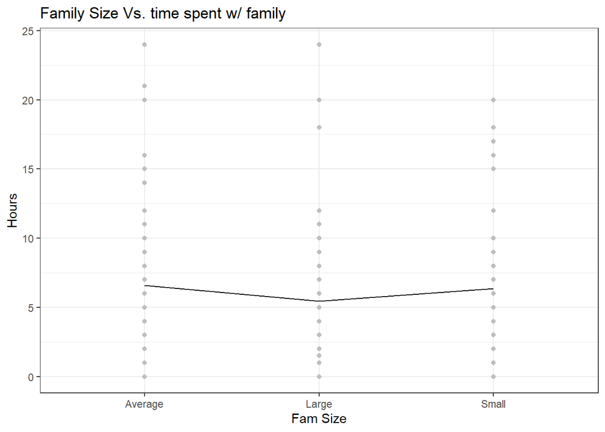

```r
ggplot(HSS_C_, aes(x=Home_Occupants_F, y=Doing_Things_With_Family_Hours, group=1)) +
  geom_point(color="gray") +
  stat_summary(fun="mean", geom="line") +
  labs(title="Family Size Vs. time spent w/ family", x="Fam Size", y="Hours") +
  theme_bw()
```

```r
HSS_C_ %>%
  group_by(Home_Occupants_F) %>%
  summarise(`Mean Fam Hours`=mean(Doing_Things_With_Family_Hours, na.rm = TRUE)) %>%
  pander(caption="Mean Hours by Fam size")
```

Mean Hours by Fam size

| Home_Occupants_F | Mean Fam Hours |
| --- | --- |
| Average | 6.585 |
| Large | 5.452 |
| Small | 6.354 |

There is not any significant variance of time spent with family due to family size.

### AOV Results

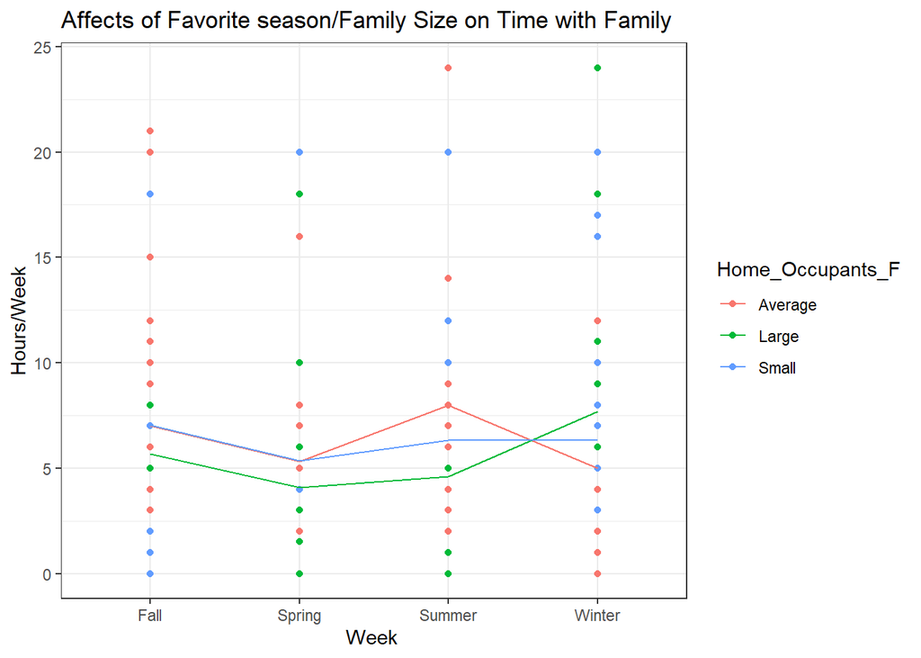

```r
ggplot(HSS_C_, aes(x=Favorite_Season, y=Doing_Things_With_Family_Hours, group=Home_Occupants_F, color=Home_Occupants_F)) +
  geom_point() +
  stat_summary(fun="mean", geom="line") +
  labs(title="Affects of Favorite season/Family Size on Time with Family", x="Week ", y="Hours/Week") +
  theme_bw()
```

Below are the Values for our test, as shown we can see that none of the p-values are significant with a level of 0.05. So there is not a significant effect on the number of hours spent with family based on Favorite Season, or Home Size. We can also see that there is no significant relationship between favorite season and home size.

```r
Fam2.aov <- aov(Doing_Things_With_Family_Hours ~ Favorite_Season + Home_Occupants_F + Favorite_Season:Home_Occupants_F, data=HSS_C_)
summary(Fam2.aov) %>% pander(caption ="Anova Results")
```

Anova Results

|  | Df | Sum Sq | Mean Sq | F value | Pr(>F) |
| --- | --- | --- | --- | --- | --- |
| **Favorite_Season** | 3 | 98.45 | 32.82 | 1.121 | 0.341 |
| **Home_Occupants_F** | 2 | 50.67 | 25.34 | 0.8658 | 0.422 |
| **Favorite_Season:Home_Occupants_F** | 6 | 210.3 | 35.06 | 1.198 | 0.3079 |
| **Residuals** | 247 | 7228 | 29.26 | NA | NA |

## Conclusion

To conclude we can see that neither of these variables or time spent with family appear to have any significant relationship. Favorite season does not affect time spent with family nor does the size of your family. Additionally favorite season does not seem to have any connection with family size. I think these values are relatively non-significant due to the fact that at least in my opinion I don’t see a reason that Favorite season would determine/be determined by Family Size. And I was not surprised by the lack of relationship between family sizes and time spent with family due to these being the same results as my previous analyses.

## Additional anova for other half of first HSS analysis.

My original Highschool analysis also included a test on the same variables but for time spent with friends rather than time spend with family. The anova results and resulting plot are shown below.

```r
Fre2.aov <- aov(Hanging_Out_With_Friends_Hours ~ Favorite_Season + Home_Occupants_F + Favorite_Season:Home_Occupants_F, data=HSS_C_)
summary(Fre2.aov) %>% pander()
```

Analysis of Variance Model

|  | Df | Sum Sq | Mean Sq | F value | Pr(>F) |
| --- | --- | --- | --- | --- | --- |
| **Favorite_Season** | 3 | 163.6 | 54.55 | 1.394 | 0.2451 |
| **Home_Occupants_F** | 2 | 19.56 | 9.782 | 0.25 | 0.779 |
| **Favorite_Season:Home_Occupants_F** | 6 | 117.3 | 19.54 | 0.4996 | 0.8084 |
| **Residuals** | 247 | 9663 | 39.12 | NA | NA |

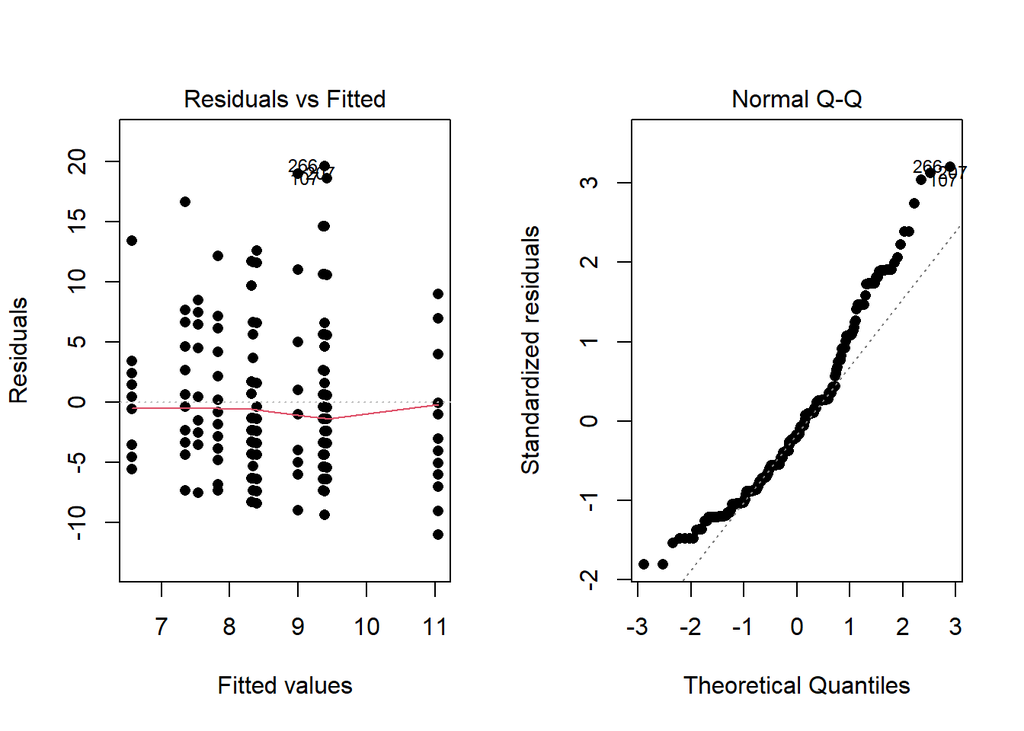

```r
par(mfrow=c(1,2))
plot(Fre2.aov, which=1:2, pch=16)
```

These results are similar to those from the above test, none of the variables are significant nor have a significant effect one on another.

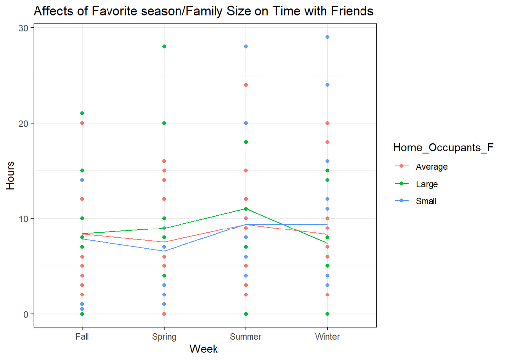

```r
ggplot(HSS_C_, aes(x=Favorite_Season, y=Hanging_Out_With_Friends_Hours, group=Home_Occupants_F, color=Home_Occupants_F)) +
  geom_point() +
  stat_summary(fun="mean", geom="line") +
  labs(title="Affects of Favorite season/Family Size on Time with Friends", x="Week ", y="Hours") +
  theme_bw()
```